# Anàlisi de la cohort de LIHC utilitzant informació de MCN

## Preparació de les dades per a l’anàlisi

El fitxer de dades amb informació de l’estat WGD (Bielski) conté 187 casos de la cohort de LIHC.

Tenim 424 fitxers de recomptes de la cohort de LIHC.

L’anàlisi inclourà 184 mostres, 129 mostres sense WGD i 55 mostres amb WGD. Un 30% de les mostres de l’anàlisi han patit WGD.

## Pre-processament de les dades

Per a la filtració s’ha utilitzat un llindar de CPM de 0.13 i s’han filtrat 39969 gens, és a dir un 66% dels gens que teníem inicialment.

El rang de valors dels factors de normalització és de 0.5388707, 1.8569163.

## Exploració de les dades

### Gràfics de densitat

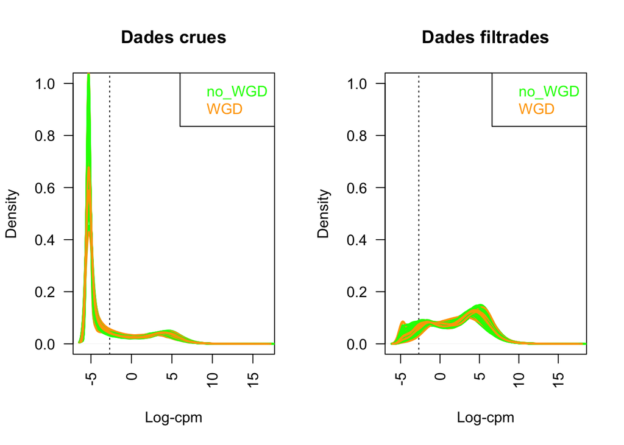

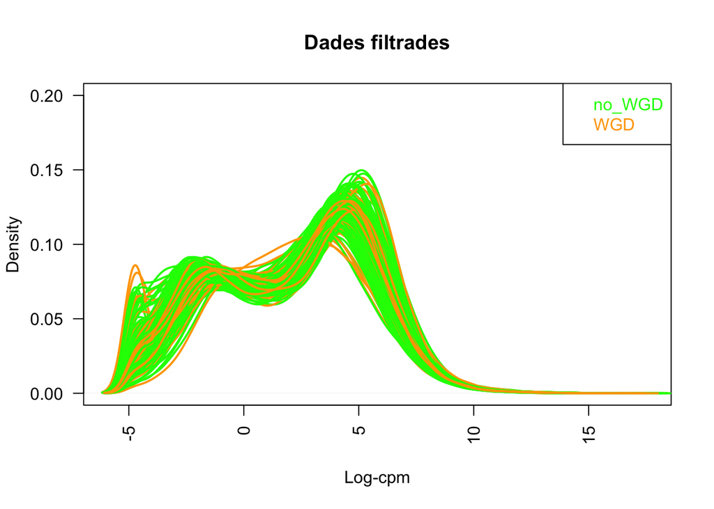

### Gràfic d’escalat multidimensional

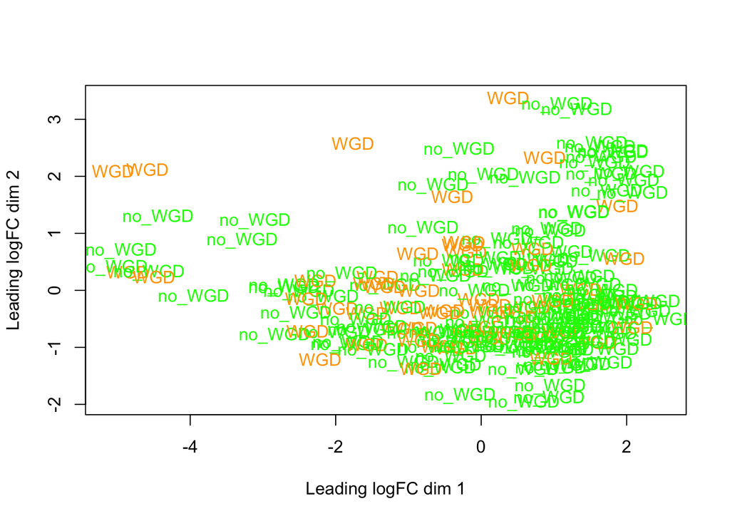

### Heatmap del gens més variables

Matriu de distàncies dels logCPM dels gens més variables. En aquest cas extraiem els 500 gens més variables a partir de les dades filtrades i normalitzades.

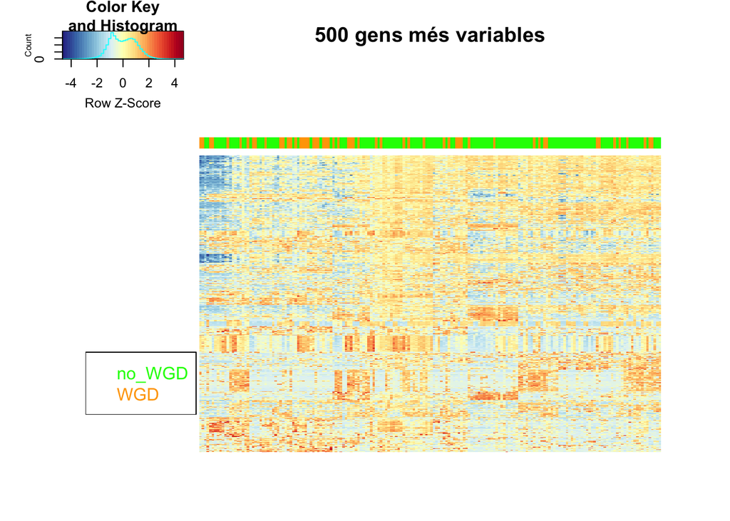

## Resultats de l’anàlisi d’expressió diferencial

### Nombre de gens diferencialment expressats

Contrastos amb p-valor ajustat (FDR) inferior a 0.05:

```
##        WGDvsNoWGD
## Down         1227
## NotSig      17793
## Up           1494
```

Contrastos amb p-valor sense ajustar inferior a 0.05 i valor absolut de log2-fold-change superior a 0.5 , aproximadament equivalent a un fold-change de 0.7 i 1.4:

```
##        WGDvsNoWGD
## Down         1409
## NotSig      18077
## Up           1028
```

### Llista de gens ordenats per significació

```
##       ensembl_gene_id hgnc_symbol      logFC      P.Value    adj.P.Val
## 2274  ENSG00000101150     TPD52L2  0.5196994 5.145059e-10 1.055457e-05
## 5184  ENSG00000125835       SNRPB  0.7128050 2.005775e-09 1.371549e-05
## 18874 ENSG00000263266      RPS7P1  0.8639212 1.510824e-09 1.371549e-05
## 16910 ENSG00000236552    RPL13AP5  0.8379792 3.413007e-09 1.750360e-05
## 2270  ENSG00000101132       PFDN4  0.6037995 1.619824e-08 4.747010e-05
## 15303 ENSG00000214078       CPNE1  0.6837017 1.435879e-08 4.747010e-05
## 17424 ENSG00000244313              0.9189888 1.458204e-08 4.747010e-05
## 11450 ENSG00000171858       RPS21  0.8743472 1.895976e-08 4.861755e-05
## 10709 ENSG00000167747    C19orf48  0.8279159 2.144414e-08 4.887833e-05
## 2288  ENSG00000101193        GID8  0.4313918 3.236916e-08 6.640210e-05
## 6945  ENSG00000138792       ENPEP -1.3273738 4.784074e-08 8.921863e-05
## 14253 ENSG00000197696         NMB  1.0503053 6.734387e-08 1.140527e-04
## 15176 ENSG00000213326     RPS7P11  0.7755678 7.227675e-08 1.140527e-04
## 2273  ENSG00000101146        RAE1  0.4338637 1.008970e-07 1.217530e-04
## 2278  ENSG00000101161       PRPF6  0.5012852 8.674257e-08 1.217530e-04
## 2285  ENSG00000101189       MRGBP  0.4611786 1.004009e-07 1.217530e-04
## 2327  ENSG00000101361       NOP56  0.6396283 9.367816e-08 1.217530e-04
## 14234 ENSG00000197580        BCO2 -1.9570696 1.229681e-07 1.241802e-04
## 14389 ENSG00000198242      RPL23A  0.7528104 1.271222e-07 1.241802e-04
## 14763 ENSG00000204392        LSM2  0.6141378 1.255953e-07 1.241802e-04
```

### Representació gràfica dels resultats

#### Gràfic mitjana-diferència

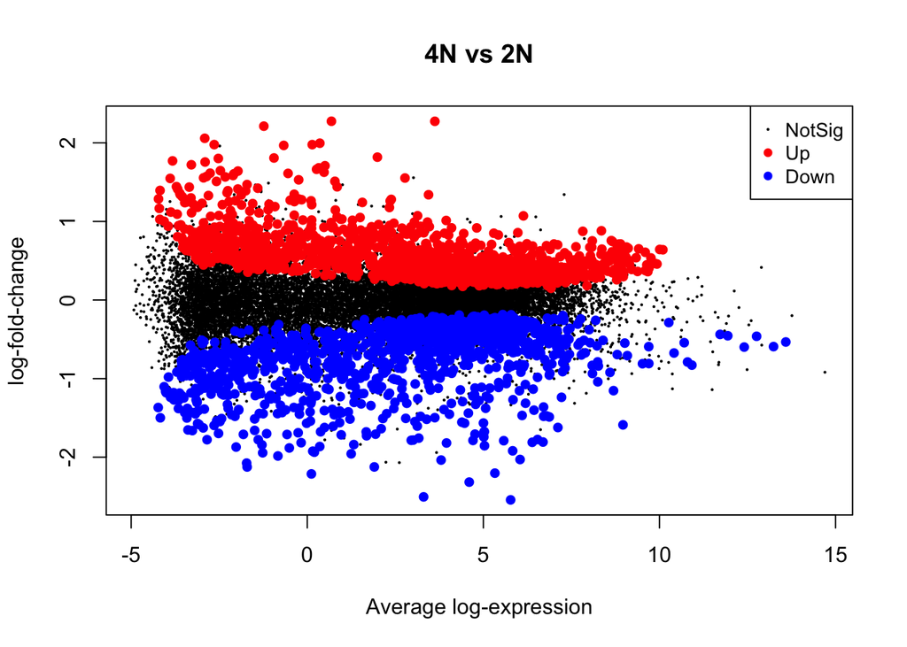

#### Gràfic de volcà

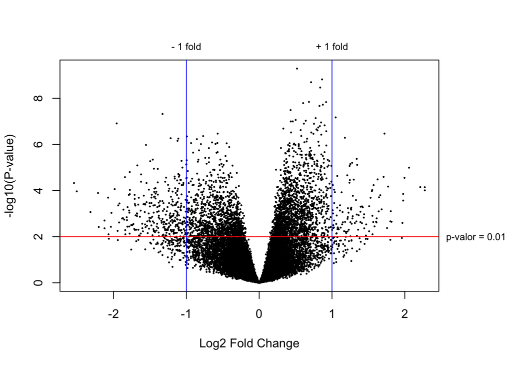

#### Heatmap dels gens més significatius

100 gens amb p-valor ajustat més baix:

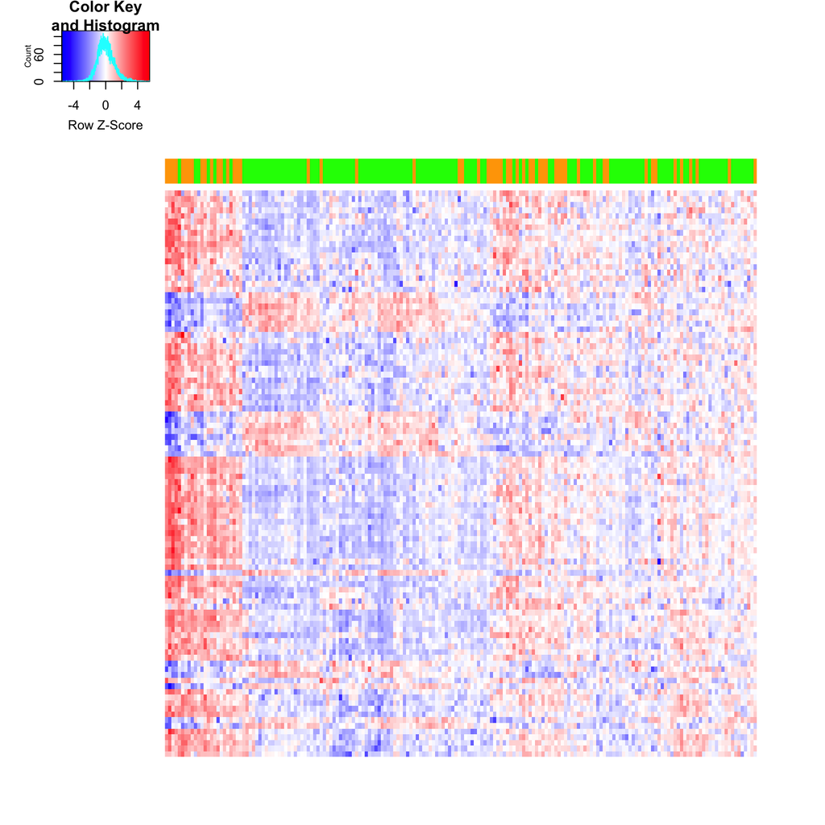

100 gens amb p-valor ajustat més baix després d’haver filtrat per aquells gens amb un logFC en valor absolut superior a 0.5 (aproximadament equivalent a FC superior a 1.4 o inferior a 0.7):

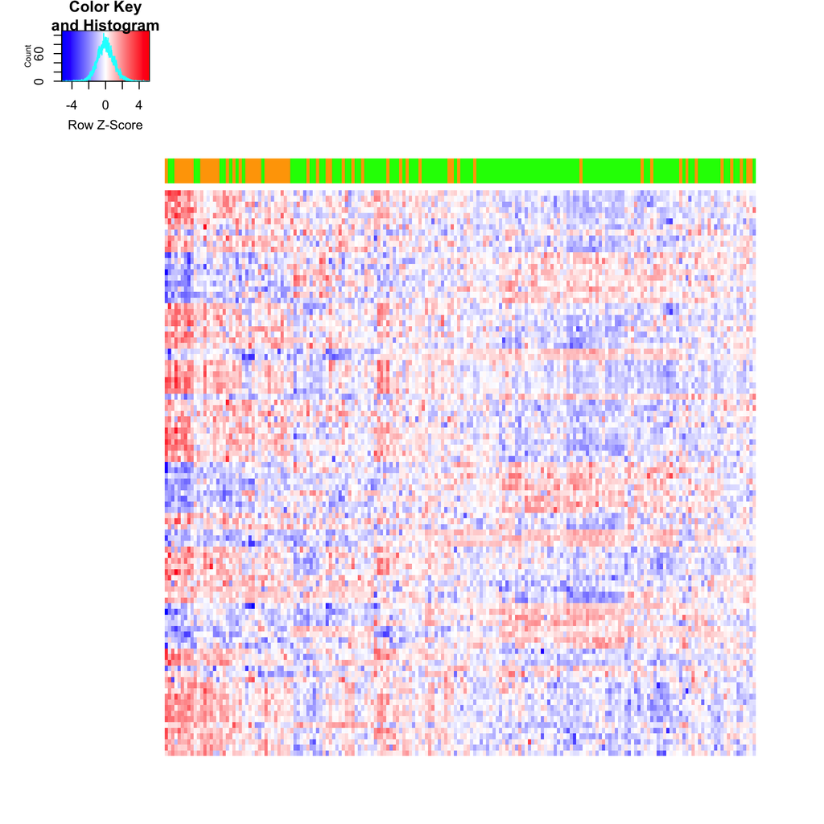

## Resultats de l’anàlisi d’enriquiment amb permutació de gene sets

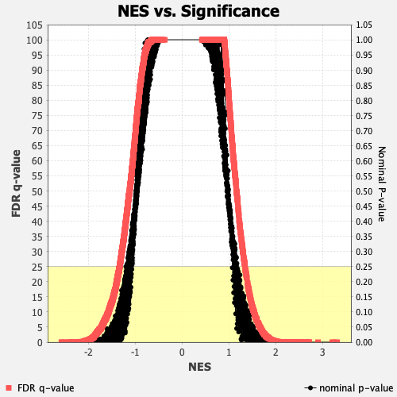

Termes enriquits al grup WGD

| NAME | FDR.q.val | NES |
| --- | --- | --- |
| GO_COTRANSLATIONAL_PROTEIN_TARGETING_TO_MEMBRANE | 0 | 3.308044 |
| GO_NUCLEAR_TRANSCRIBED_MRNA_CATABOLIC_PROCESS_NONSENSE_MEDIATED_DECAY | 0 | 3.246545 |
| GO_ESTABLISHMENT_OF_PROTEIN_LOCALIZATION_TO_ENDOPLASMIC_RETICULUM | 0 | 3.201240 |
| GO_PROTEIN_LOCALIZATION_TO_ENDOPLASMIC_RETICULUM | 0 | 2.900540 |
| GO_RIBOSOME_BIOGENESIS | 0 | 2.710395 |
| GO_MITOTIC_SISTER_CHROMATID_SEGREGATION | 0 | 2.702122 |
| GO_RRNA_METABOLIC_PROCESS | 0 | 2.697629 |
| GO_RIBONUCLEOPROTEIN_COMPLEX_BIOGENESIS | 0 | 2.691880 |
| GO_SISTER_CHROMATID_SEGREGATION | 0 | 2.669961 |
| GO_TRANSLATIONAL_INITIATION | 0 | 2.646620 |
| GO_REGULATION_OF_CHROMOSOME_SEGREGATION | 0 | 2.629335 |
| GO_VIRAL_GENE_EXPRESSION | 0 | 2.616745 |
| GO_RIBOSOME_ASSEMBLY | 0 | 2.613942 |
| GO_NUCLEAR_TRANSCRIBED_MRNA_CATABOLIC_PROCESS | 0 | 2.532106 |
| GO_REGULATION_OF_SISTER_CHROMATID_SEGREGATION | 0 | 2.530564 |
| GO_RIBOSOMAL_LARGE_SUBUNIT_BIOGENESIS | 0 | 2.529565 |
| GO_PROTEIN_TARGETING_TO_MEMBRANE | 0 | 2.495460 |
| GO_REGULATION_OF_CHROMOSOME_SEPARATION | 0 | 2.494518 |
| GO_NUCLEAR_CHROMOSOME_SEGREGATION | 0 | 2.487258 |
| GO_CELL_CYCLE_DNA_REPLICATION | 0 | 2.482938 |

Termes enriquits al grup no_WGD

| NAME | FDR.q.val | NES |
| --- | --- | --- |
| GO_MONOCARBOXYLIC_ACID_CATABOLIC_PROCESS | 0.0000000 | -2.583868 |
| GO_ORGANIC_ACID_CATABOLIC_PROCESS | 0.0000000 | -2.575964 |
| GO_FATTY_ACID_CATABOLIC_PROCESS | 0.0000000 | -2.509344 |
| GO_CELLULAR_AMINO_ACID_CATABOLIC_PROCESS | 0.0000000 | -2.455869 |
| GO_XENOBIOTIC_METABOLIC_PROCESS | 0.0000000 | -2.403204 |
| GO_REGULATION_OF_TUBE_SIZE | 0.0000000 | -2.402595 |
| GO_FATTY_ACID_METABOLIC_PROCESS | 0.0000000 | -2.368738 |
| GO_CELLULAR_LIPID_CATABOLIC_PROCESS | 0.0000000 | -2.354775 |
| GO_ALPHA_AMINO_ACID_CATABOLIC_PROCESS | 0.0000000 | -2.349789 |
| GO_LIPID_OXIDATION | 0.0001213 | -2.291748 |
| GO_VASCULAR_PROCESS_IN_CIRCULATORY_SYSTEM | 0.0001103 | -2.280123 |
| GO_LIPID_CATABOLIC_PROCESS | 0.0002025 | -2.273867 |
| GO_SMALL_MOLECULE_CATABOLIC_PROCESS | 0.0001869 | -2.267987 |
| GO_REGULATION_OF_VASOCONSTRICTION | 0.0006072 | -2.234003 |
| GO_NEGATIVE_REGULATION_OF_BLOOD_VESSEL_DIAMETER | 0.0005667 | -2.210258 |
| GO_CELLULAR_RESPONSE_TO_XENOBIOTIC_STIMULUS | 0.0008366 | -2.203280 |
| GO_TRIGLYCERIDE_METABOLIC_PROCESS | 0.0010048 | -2.189184 |
| GO_FATTY_ACID_BETA_OXIDATION | 0.0010177 | -2.183608 |
| GO_LONG_CHAIN_FATTY_ACID_METABOLIC_PROCESS | 0.0014777 | -2.165704 |
| GO_NEUROTRANSMITTER_METABOLIC_PROCESS | 0.0014038 | -2.163219 |

## Anàlisis d’immunitat

### ESTIMATE

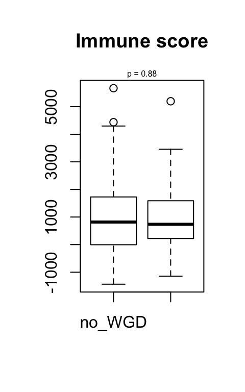

### Immunophenoscore

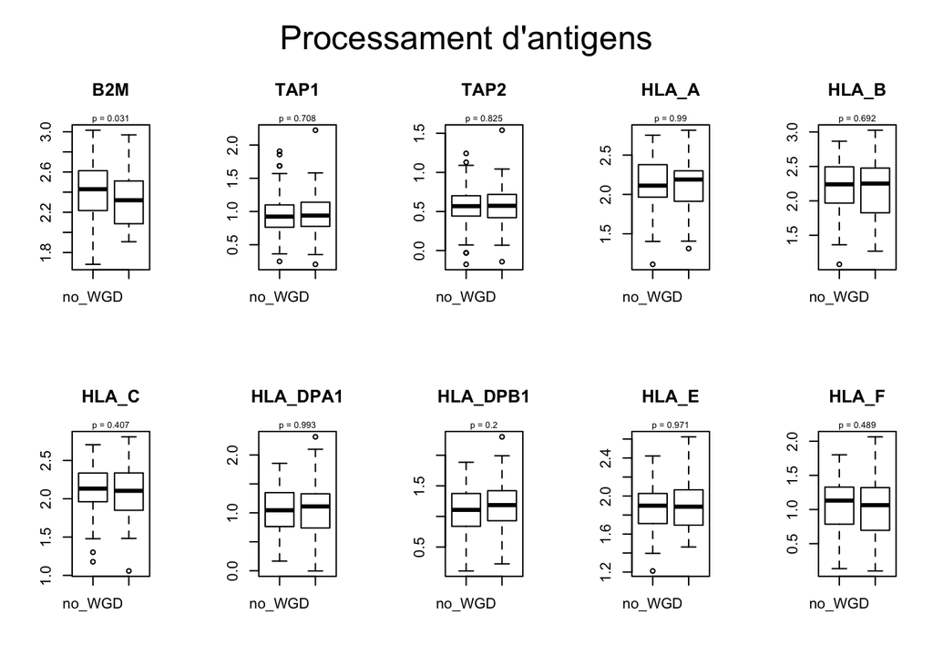

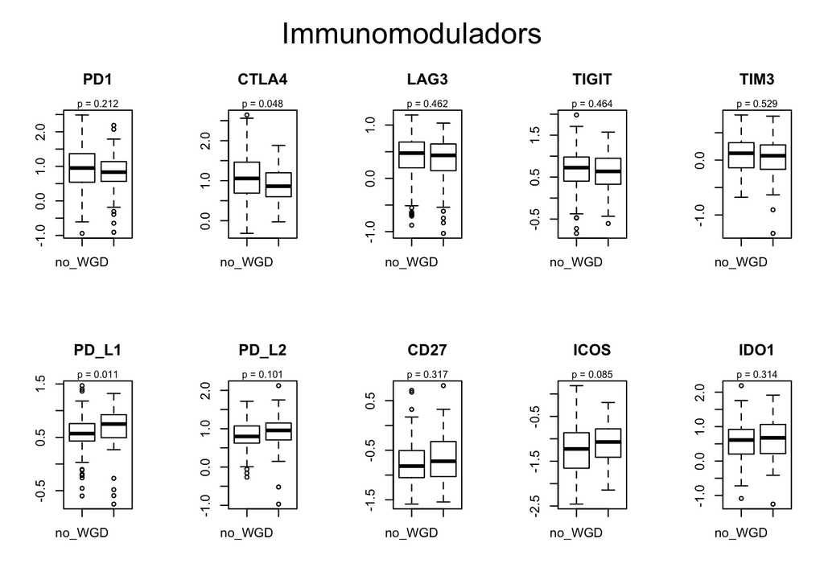

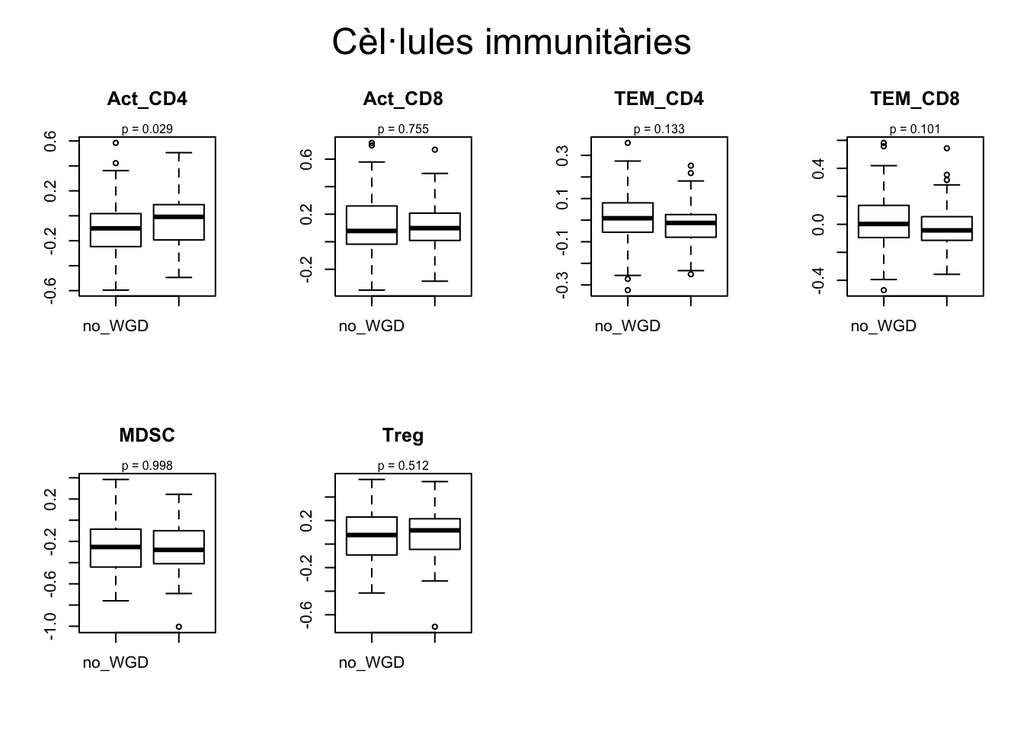

### Signatura 12-Chemokines

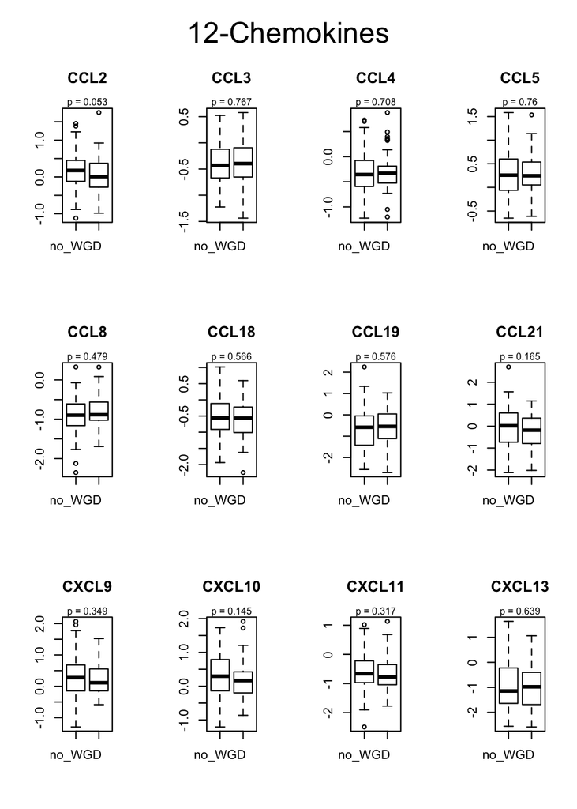